# Mapping-based analysis

Thomas W. Battaglia

```r
# simplest default settings
sciRmdTheme::set.theme()
```

## Abstract

Microbial communities are resident to multiple niches of the human body and are important modulators of the host immune system and responses to anticancer therapies. Recent studies have shown that complex microbial communities are present within primary tumors. To investigate the presence and relevance of the microbiome in metastases, we integrated mapping and assembly-based metagenomics, genomics, transcriptomics, and clinical data of 4,160 metastatic tumor biopsies. We identified organ-specific tropisms of microbes, enrichments of anaerobic bacteria in hypoxic tumors, associations between microbial diversity and tumor-infiltrating neutrophils, and the association of Fusobacterium with resistance to immune checkpoint blockade (ICB) in lung cancer. Furthermore, longitudinal tumor sampling revealed temporal evolution of the microbial communities and identified bacteria depleted upon ICB. Together, we generated a pan-cancer resource of the metastatic tumor microbiome which may contribute to advancing treatment strategies.

## Purpose

The purpose of this document is to provide transparency and reproducibility to the analyses presented in our manuscript. Each figure in the manuscript corresponds to code and explanations provided herein, ensuring clarity and facilitating further exploration or replication of the results.

The document is structured in a manner that each figure in the manuscript is dissected. This breakdown includes data preparation, statistical analyses and visualization techniques.

It’s important to note that while we strive for transparency, some data cannot be shared due to patient privacy regulations. In such cases, we provide descriptions of the analyses performed without disclosing sensitive data.

## Import data

### From MicrobeDS

```r
# Import phyloseq object directly
# install.packages("remotes")
# remotes::install_github("twbattaglia/MicrobeDS")
library(MicrobeDS)

# Load data
data("Hartwig")

# Check number of samples
nsamples(Hartwig)
```

```
## [1] 3574
```

```r
# Check sample metadata
sample_data(Hartwig) %>%
  head()
```

```
##            hmfSampleId hmfPatientId tumorPurity primaryTumorLocation
## HMF002684A  HMF002684A    HMF002684        0.50     Bone/Soft tissue
## HMF000990A  HMF000990A    HMF000990        0.31                  CUP
## HMF002764A  HMF002764A    HMF002764        0.38               Breast
## HMF003578A  HMF003578A    HMF003578        0.67      Small intestine
## HMF003787A  HMF003787A    HMF003787        0.54                 Lung
## HMF001423C  HMF001423C    HMF001423        0.43               Breast
##            primaryTumorSubLocation               primaryTumorType
## HMF002684A                    <NA> Gastrointestinal stromal tumor
## HMF000990A                     CUP                      Carcinoma
## HMF002764A                    <NA>                      Carcinoma
## HMF003578A                    <NA>           Neuroendocrine tumor
## HMF003787A                    <NA>                      Carcinoma
## HMF001423C                    <NA>                      Carcinoma
##                  primaryTumorSubType             biopsySite    treatmentType
## HMF002684A                      <NA> Abdomen/Abdominal wall Targeted therapy
## HMF000990A                      <NA>                  Liver    Not available
## HMF002764A ER-positive/HER2-negative             Lymph node Hormonal therapy
## HMF003578A                      <NA>                  Liver Hormonal therapy
## HMF003787A  Non-small cell carcinoma            (Sub)cutane    Immunotherapy
## HMF001423C           Triple negative                 Breast     Chemotherapy
##            gender firstResponse sequencerType initial.reads initial.mapped
## HMF002684A female            SD         HiSeq    4524074728     4463368182
## HMF000990A female          NULL         HiSeq    4847672834     4811283078
## HMF002764A female          NULL         HiSeq    5942275302     5911821654
## HMF003578A   male            SD         HiSeq    4622896796     4604390750
## HMF003787A   male            PD         HiSeq    5389091866     5359956746
## HMF001423C female            SD         HiSeq    5044321256     5017661944
```

### Attributes

```r
aerophilicity = read_csv("data/aerophilicity.csv") %>%
  filter(Score > 0.5) %>%
  mutate(NCBI_ID = as.character(NCBI_ID)) %>%
  mutate(Attribute2 = case_when(
    Attribute %in% c(":aerobic", ":obligately_aerobic") ~ "Aerobic",
    Attribute %in% c(":anaerobic", ":obligately_anaerobic") ~ "Anaerobic",
    Attribute %in% c(":facultatively_anaerobic") ~ "Facultatively anaerobic",
    Attribute %in% c(":microaerophilic") ~ "microaerophilic",
    Attribute %in% c("missing") ~ "missing"
  ))
gram_status = read_csv("data/gram_status.csv") %>%
  filter(Score > 0.5) %>%
  mutate(NCBI_ID = as.character(NCBI_ID))
```

```r
# Set colors
o2status.colors = c("Aerobic" = "#D36135",
                    "Anaerobic" = "#7FB069",
                    "Facultatively anaerobic" = "#ECE4B7",
                    "microaerophilic" = "#E6AA68",
                    "Not available" = "gray")
gram.colors = c("Gram-" = "#DFBBB1", "Gram+" = "#726DA8", "Not available" = "gray")

primary.colors = microViz::distinct_palette(n = 20, pal = "brewerPlus", add = "lightgrey")
names(primary.colors) = meta(Hartwig)$primaryTumorLocation %>% unique()
```

## Computationally profiling the tumor microbiome of 4,160 metastatic cancer samples. (Fig. 1)

### Phylogenetic tree

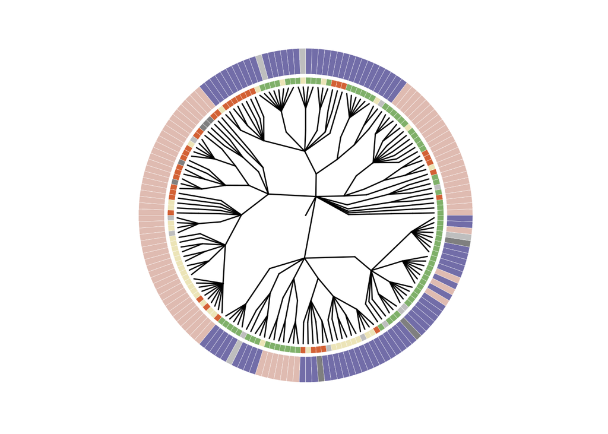

```r
# Import graphlan tree
tree.genus = treeio::read.phyloxml("data/graphlan.genus.xml")
taxtable.df = tax_table(Hartwig) %>% as.data.frame() %>% rownames_to_column("taxId")

# Make phylogenetic tree
p <- ggtree::ggtree(tree.genus, layout="radial", open.angle=15, size=0.50)
p <- p %<+% column_to_rownames(taxtable.df, "Genus")

# Get annoation dataframes
o2.anno = taxtable.df %>%
  left_join(aerophilicity, by = c("taxId" = "NCBI_ID")) %>%
  column_to_rownames("Genus") %>%
  mutate(Attribute2 = replace_na(Attribute2, "Not available")) %>%
  mutate(Attribute2 = if_else(Attribute2 == "microaerophilic", "Microaerophilic", Attribute2)) %>%
  select(Attribute2)

gram.anno = taxtable.df %>%
  left_join(gram_status, by = c("taxId" = "NCBI_ID")) %>%
  column_to_rownames("Genus") %>%
  mutate(Attribute = replace_na(Attribute, "Not available")) %>%
  mutate(Attribute = fct_recode(Attribute,
                                "Gram-" = ":gram_stain_negative",
                                "Gram+" = ":gram_stain_positive",
                                "Variable" = ":gram_stain_variable")) %>%
  select(Attribute)

p1 = ggtree::gheatmap(p, o2.anno, offset = 0.001, width = 0.05, colnames_offset_y = 0.01, colnames = F) +
  scale_fill_manual(values = o2status.colors)
library(ggnewscale)
p2 <- p1 + new_scale_fill()

p = gheatmap(p2, gram.anno, offset=0.005, width=0.20, colnames_angle=90, colnames_offset_y = 0.01, colnames = F) +
  scale_fill_manual(values = gram.colors)
p = p + theme(panel.grid.major = element_blank(),
              panel.grid.minor = element_blank(),
              panel.background = element_rect(fill = "transparent" ,colour = NA),
              plot.background = element_rect(fill = "transparent", colour = NA),
              legend.position = "none")
p
```

```r
ggsave('figures/figure1/Figure-1A.pdf', p,  width = 5.25, height = 5.25,  bg = "transparent")
```

### Sample overview

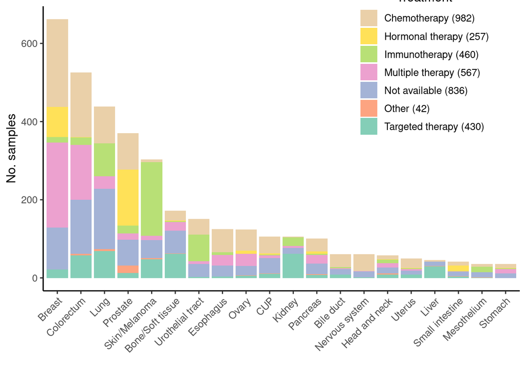

```r
trt.colors = pal_npg("nrc", alpha = 0.7)(10)
names(trt.colors) = meta(Hartwig)$treatmentType %>%  as.factor() %>% levels()
trt.colors["Not available"] = "gray"

# Number of samples of primary
primary.freq = meta(Hartwig) %>%
  count(primaryTumorLocation, treatmentType, name = "count") %>%
  rename(Treatment = treatmentType) %>%
  mutate(Treatment = fct_lump_min(Treatment, min = 10)) %>%
  mutate(primaryTumorLocation = if_else(primaryTumorLocation == "Melanoma", "Skin/Melanoma", primaryTumorLocation)) %>%
  mutate(primaryTumorLocation = fct_reorder(primaryTumorLocation, -count, sum)) %>%
  group_by(Treatment) %>%
  mutate(n_trt = sum(count)) %>%
  mutate(Treatment = paste0(Treatment, " (", n_trt, ")")) %>%
  ggplot(aes(x = primaryTumorLocation, y = count, fill = Treatment)) +
  geom_col(alpha = 0.80) +
  theme_classic(base_family = 'Helvetica', base_size = 12) +
  theme(legend.position = c(0.80, 0.80),
        legend.title=element_blank()) +
  guides(fill = guide_legend(title.position="top", title.hjust = 0.5)) +
  scale_fill_brewer(palette = "Set2", direction = -1) +
  ggpubr::rotate_x_text(45) +
  ylab("No. samples") +
  xlab("")
primary.freq
```

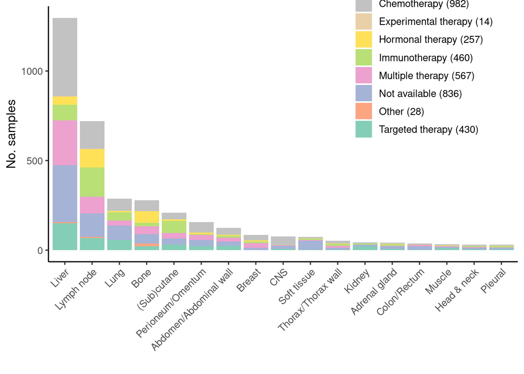

```r
ggsave("figures/figure1/Figure-1B.pdf", primary.freq, height = 6.5, width = 12)

# Same but for biopsy site
biopsy.freq = meta(Hartwig) %>%
  count(biopsySite, treatmentType, name = "count") %>%
  rename(Treatment = treatmentType) %>%
  mutate(Treatment = fct_lump_min(Treatment, min = 10)) %>%
  mutate(biopsySite = fct_reorder(biopsySite, -count, sum)) %>%
  group_by(Treatment) %>%
  mutate(n_trt = sum(count)) %>%
  mutate(Treatment = paste0(Treatment, " (", n_trt, ")")) %>%
  ggplot(aes(x = biopsySite, y = count, fill = Treatment)) +
  geom_col(alpha = 0.80) +
  theme_classic(base_family = 'Helvetica', base_size = 12) +
  theme(legend.position = c(0.80, 0.80),
        legend.title=element_blank()) +
  guides(fill = guide_legend(title.position="top", title.hjust = 0.5)) +
  scale_fill_brewer(palette = "Set2", direction = -1) +
  ggpubr::rotate_x_text(45) +
  ylab("No. samples") +
  xlab("")

biopsy.freq
```

### Frac. reads

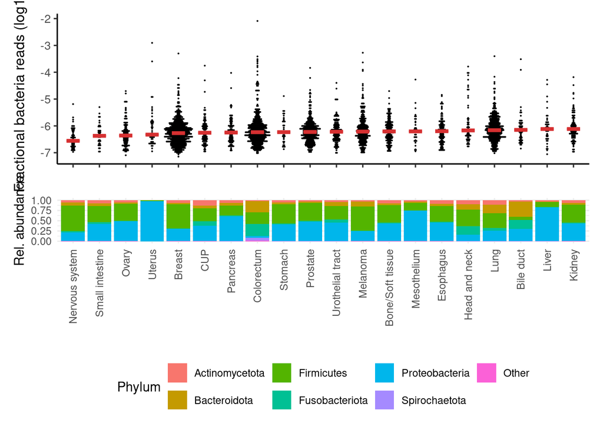

```r
bacterial.reads = Hartwig %>%
  subset_taxa(Kingdom == "Bacteria") %>%
  sample_sums() %>%
  data.frame(bacterial.reads = .) %>%
  rownames_to_column("hmfSampleId")

mapped.reads.data = Hartwig %>%
  meta() %>%
  mutate(initial.mapped = if_else(is.na(initial.mapped), median(initial.mapped, na.rm = T), initial.mapped)) %>%
  left_join(bacterial.reads) %>%
  mutate(fractional_bacterial = log10(bacterial.reads / initial.mapped)) %>%
  select(hmfSampleId, fractional_bacterial) %>%
  filter(!is.na(fractional_bacterial))
fraction.top.plot = Hartwig %>%
  meta() %>%
  inner_join(mapped.reads.data) %>%
  mutate(primaryTumorLocation = fct_reorder(primaryTumorLocation, fractional_bacterial, median)) %>%
  ggplot(aes(x = primaryTumorLocation, y = fractional_bacterial, fill = primaryTumorLocation)) +
  geom_dotplot(binaxis = "y",
              binwidth = 0.035,
              stackdir = "center") +
  stat_summary(fun.y = median, fun.ymin = median, fun.ymax = median, geom = "crossbar", fatten = 3, width = 0.5, color = "#d63031", alpha = 0.50) +
  theme_classic2() +
  theme(legend.position = "none",
        axis.text.x = element_blank()) +
  scale_fill_manual(values = primary.colors) +
  xlab("") +
  ylab('Fractional bacteria reads (log10)')
# phylogeny plot (average)
fraction.bottom = Hartwig %>%
  microbiomeutilities::aggregate_top_taxa2(top = 6, level = "Phylum") %>%
  psmelt() %>%
  inner_join(mapped.reads.data) %>%
  mutate(primaryTumorLocation = fct_reorder(primaryTumorLocation, fractional_bacterial, median)) %>%
  group_by(primaryTumorLocation, Phylum) %>%
  summarise(mean = mean(Abundance)) %>%
  group_by(primaryTumorLocation) %>%
  mutate(relative.abundance = mean / sum(mean))
fraction.bottom.plot = fraction.bottom %>%
  mutate(Phylum = if_else(Phylum == "Bacillota", "Firmicutes", Phylum)) %>%
  mutate(Phylum = if_else(Phylum == "Pseudomonadota", "Proteobacteria", Phylum)) %>%
  mutate(Phylum = fct_relevel(Phylum, "Other", after = 6)) %>%
  ggplot(aes(x = primaryTumorLocation, y = relative.abundance, fill = Phylum)) +
  geom_col() +
  theme_minimal() +
  theme(legend.position = "bottom") +
  ggpubr::rotate_x_text(90) +
  xlab("") +
  ylab("Rel. abundance")

p = (fraction.top.plot / fraction.bottom.plot) + plot_layout(heights = c(5,1.5))
p
```

```r
ggsave("figures/figure1/Figure-1D.pdf", p, height = 6.5, width = 12)
```

## Characteristics of the tumor microbiome in metastatic cancer (Fig. 2)

## Associations of the microbiome with tumor physiology (Fig. 3)

## Dynamics of the tumor microbiome over the course of systemic anticancer treatment (Fig. 4)

## Fusobacterium presence is negatively associated with response to ICB in NSCLC (Fig. 5)